# Selection subset, Ridge/LASSO, PCR and PLS

Hajin Jang

11/11/2025

## Best subset selection

```r
library(ISLR2)
library(glmnet)
library(leaps)
library(pls)
```

#### A predictor $X$ of length $n = 100$, noise vector $\epsilon$ of length $n = 100$.

```r
set.seed(1)
X <- rnorm(100)
eps <- rnorm(100)
```

#### A response vector $Y$ of length $n = 100$ according to the model $$Y = \beta_0 + \beta_1X + \beta_2X^2 + \beta_3X^3 + \epsilon,$$ where $\beta_0, \beta_1, \beta_2,$ and $\beta_3$

```r
beta0 = 3
beta1 = 2
beta2 = -3
beta3 = 0.3
Y = beta0 + beta1 * X + beta2 * X^2 + beta3 * X^3 + eps
```

**Comment:** I used beta0=3, beta1=2, beta2=-3, and beta3=0.3.

#### Best model selection containing the predictors $X, X^2, ..., X^{10}$

```r
data.full = data.frame(y = Y, x = X)
mod.full = regsubsets(y ~ poly(x, 10, raw = T), data = data.full, nvmax = 10)
mod.summary = summary(mod.full)
mod.summary
```

```
## Subset selection object
## Call: regsubsets.formula(y ~ poly(x, 10, raw = T), data = data.full,
##     nvmax = 10)
## 10 Variables  (and intercept)
##                        Forced in Forced out
## poly(x, 10, raw = T)1      FALSE      FALSE
## poly(x, 10, raw = T)2      FALSE      FALSE
## poly(x, 10, raw = T)3      FALSE      FALSE
## poly(x, 10, raw = T)4      FALSE      FALSE
## poly(x, 10, raw = T)5      FALSE      FALSE
## poly(x, 10, raw = T)6      FALSE      FALSE
## poly(x, 10, raw = T)7      FALSE      FALSE
## poly(x, 10, raw = T)8      FALSE      FALSE
## poly(x, 10, raw = T)9      FALSE      FALSE
## poly(x, 10, raw = T)10     FALSE      FALSE
## 1 subsets of each size up to 10
## Selection Algorithm: exhaustive
##           poly(x, 10, raw = T)1 poly(x, 10, raw = T)2 poly(x, 10, raw = T)3
## 1  ( 1 )  " "                   "*"                   " "
## 2  ( 1 )  "*"                   "*"                   " "
## 3  ( 1 )  "*"                   "*"                   " "
## 4  ( 1 )  "*"                   "*"                   " "
## 5  ( 1 )  "*"                   "*"                   " "
## 6  ( 1 )  "*"                   "*"                   " "
## 7  ( 1 )  "*"                   "*"                   " "
## 8  ( 1 )  "*"                   "*"                   " "
## 9  ( 1 )  "*"                   "*"                   " "
## 10  ( 1 ) "*"                   "*"                   "*"
##           poly(x, 10, raw = T)4 poly(x, 10, raw = T)5 poly(x, 10, raw = T)6
## 1  ( 1 )  " "                   " "                   " "
## 2  ( 1 )  " "                   " "                   " "
## 3  ( 1 )  " "                   " "                   " "
## 4  ( 1 )  " "                   "*"                   "*"
## 5  ( 1 )  " "                   " "                   " "
## 6  ( 1 )  " "                   " "                   "*"
## 7  ( 1 )  "*"                   " "                   "*"
## 8  ( 1 )  "*"                   "*"                   "*"
## 9  ( 1 )  "*"                   "*"                   "*"
## 10  ( 1 ) "*"                   "*"                   "*"
##           poly(x, 10, raw = T)7 poly(x, 10, raw = T)8 poly(x, 10, raw = T)9
## 1  ( 1 )  " "                   " "                   " "
## 2  ( 1 )  " "                   " "                   " "
## 3  ( 1 )  "*"                   " "                   " "
## 4  ( 1 )  " "                   " "                   " "
## 5  ( 1 )  "*"                   "*"                   "*"
## 6  ( 1 )  "*"                   "*"                   " "
## 7  ( 1 )  "*"                   "*"                   " "
## 8  ( 1 )  " "                   "*"                   "*"
## 9  ( 1 )  "*"                   "*"                   "*"
## 10  ( 1 ) "*"                   "*"                   "*"
##           poly(x, 10, raw = T)10
## 1  ( 1 )  " "
## 2  ( 1 )  " "
## 3  ( 1 )  " "
## 4  ( 1 )  " "
## 5  ( 1 )  " "
## 6  ( 1 )  "*"
## 7  ( 1 )  "*"
## 8  ( 1 )  "*"
## 9  ( 1 )  "*"
## 10  ( 1 ) "*"
```

```r
# Model size (cp, BIC, adjr2)
which.min(mod.summary$cp)
```

```
## [1] 3
```

```r
which.min(mod.summary$bic)
```

```
## [1] 3
```

```r
which.max(mod.summary$adjr2)
```

```
## [1] 3
```

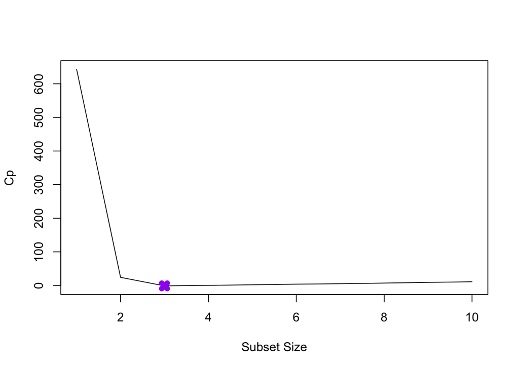

```r
# Plot (cp, BIC, adjr2)
plot(mod.summary$cp, xlab = "Subset Size", ylab = "Cp", pch = 20, type = "l")
points(3, mod.summary$cp[3], pch = 4, col = "purple", lwd = 7)
```

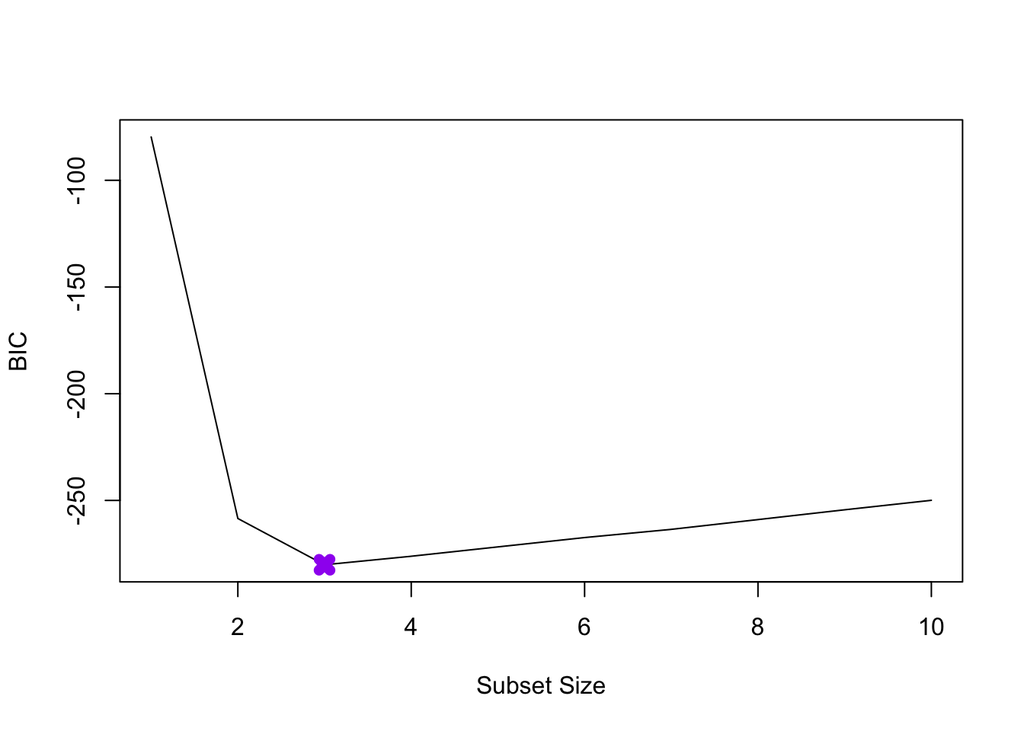

```r
plot(mod.summary$bic, xlab = "Subset Size", ylab = "BIC", pch = 20, type = "l")
points(3, mod.summary$bic[3], pch = 4, col = "purple", lwd = 7)
```

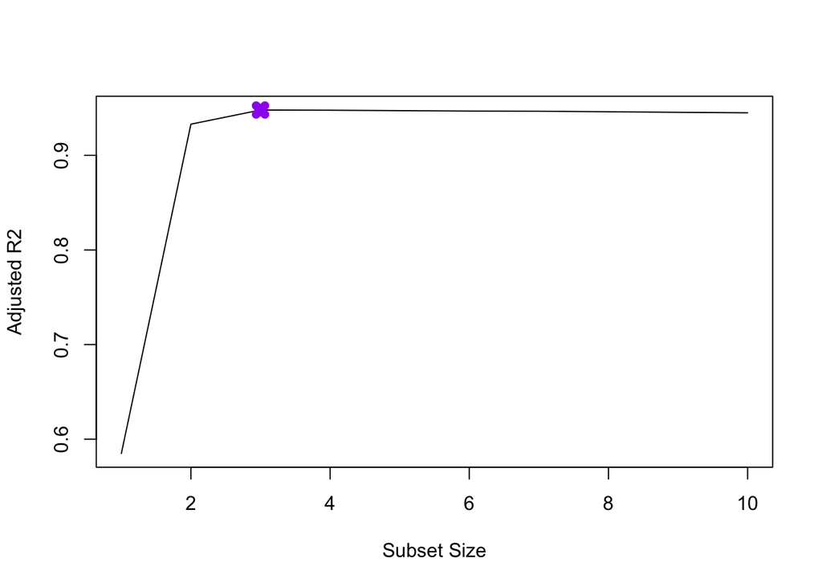

```r
plot(mod.summary$adjr2, xlab = "Subset Size", ylab = "Adjusted R2", pch = 20, type = "l")
points(3, mod.summary$adjr2[3], pch = 4, col = "purple", lwd = 7)
```

```r
coefficients(mod.full, id = 3)
```

```
##           (Intercept) poly(x, 10, raw = T)1 poly(x, 10, raw = T)2
##            3.07627412            2.35623596           -3.16514887
## poly(x, 10, raw = T)7
##            0.01046843
```

**Comment:** Based on the Cp, BIC, and Adjusted $R^2$ criteria, all three methods selected the model with three variables. Each criterion favored $X^7$ over $X^3$. The estimated coefficients were close to the true $\beta$ values, with $\hat{\beta}_0 = 3.076$, $\hat{\beta}_1 = 2.356$, $\hat{\beta}_2 = -3.165$, and $\hat{\beta}_3 = 0.010$.

#### Forwards/backwards stepwise selection

```r
mod.fwd = regsubsets(y ~ poly(x, 10, raw = T), data = data.full, nvmax = 10, method = "forward")
mod.bwd = regsubsets(y ~ poly(x, 10, raw = T), data = data.full, nvmax = 10, method = "backward")

fwd.summary = summary(mod.fwd)
bwd.summary = summary(mod.bwd)
fwd.summary
```

```
## Subset selection object
## Call: regsubsets.formula(y ~ poly(x, 10, raw = T), data = data.full,
##     nvmax = 10, method = "forward")
## 10 Variables  (and intercept)
##                        Forced in Forced out
## poly(x, 10, raw = T)1      FALSE      FALSE
## poly(x, 10, raw = T)2      FALSE      FALSE
## poly(x, 10, raw = T)3      FALSE      FALSE
## poly(x, 10, raw = T)4      FALSE      FALSE
## poly(x, 10, raw = T)5      FALSE      FALSE
## poly(x, 10, raw = T)6      FALSE      FALSE
## poly(x, 10, raw = T)7      FALSE      FALSE
## poly(x, 10, raw = T)8      FALSE      FALSE
## poly(x, 10, raw = T)9      FALSE      FALSE
## poly(x, 10, raw = T)10     FALSE      FALSE
## 1 subsets of each size up to 10
## Selection Algorithm: forward
##           poly(x, 10, raw = T)1 poly(x, 10, raw = T)2 poly(x, 10, raw = T)3
## 1  ( 1 )  " "                   "*"                   " "
## 2  ( 1 )  "*"                   "*"                   " "
## 3  ( 1 )  "*"                   "*"                   " "
## 4  ( 1 )  "*"                   "*"                   " "
## 5  ( 1 )  "*"                   "*"                   " "
## 6  ( 1 )  "*"                   "*"                   " "
## 7  ( 1 )  "*"                   "*"                   " "
## 8  ( 1 )  "*"                   "*"                   "*"
## 9  ( 1 )  "*"                   "*"                   "*"
## 10  ( 1 ) "*"                   "*"                   "*"
##           poly(x, 10, raw = T)4 poly(x, 10, raw = T)5 poly(x, 10, raw = T)6
## 1  ( 1 )  " "                   " "                   " "
## 2  ( 1 )  " "                   " "                   " "
## 3  ( 1 )  " "                   " "                   " "
## 4  ( 1 )  "*"                   " "                   " "
## 5  ( 1 )  "*"                   " "                   " "
## 6  ( 1 )  "*"                   " "                   "*"
## 7  ( 1 )  "*"                   "*"                   "*"
## 8  ( 1 )  "*"                   "*"                   "*"
## 9  ( 1 )  "*"                   "*"                   "*"
## 10  ( 1 ) "*"                   "*"                   "*"
##           poly(x, 10, raw = T)7 poly(x, 10, raw = T)8 poly(x, 10, raw = T)9
## 1  ( 1 )  " "                   " "                   " "
## 2  ( 1 )  " "                   " "                   " "
## 3  ( 1 )  "*"                   " "                   " "
## 4  ( 1 )  "*"                   " "                   " "
## 5  ( 1 )  "*"                   " "                   "*"
## 6  ( 1 )  "*"                   " "                   "*"
## 7  ( 1 )  "*"                   " "                   "*"
## 8  ( 1 )  "*"                   " "                   "*"
## 9  ( 1 )  "*"                   "*"                   "*"
## 10  ( 1 ) "*"                   "*"                   "*"
##           poly(x, 10, raw = T)10
## 1  ( 1 )  " "
## 2  ( 1 )  " "
## 3  ( 1 )  " "
## 4  ( 1 )  " "
## 5  ( 1 )  " "
## 6  ( 1 )  " "
## 7  ( 1 )  " "
## 8  ( 1 )  " "
## 9  ( 1 )  " "
## 10  ( 1 ) "*"
```

```r
bwd.summary
```

```
## Subset selection object
## Call: regsubsets.formula(y ~ poly(x, 10, raw = T), data = data.full,
##     nvmax = 10, method = "backward")
## 10 Variables  (and intercept)
##                        Forced in Forced out
## poly(x, 10, raw = T)1      FALSE      FALSE
## poly(x, 10, raw = T)2      FALSE      FALSE
## poly(x, 10, raw = T)3      FALSE      FALSE
## poly(x, 10, raw = T)4      FALSE      FALSE
## poly(x, 10, raw = T)5      FALSE      FALSE
## poly(x, 10, raw = T)6      FALSE      FALSE
## poly(x, 10, raw = T)7      FALSE      FALSE
## poly(x, 10, raw = T)8      FALSE      FALSE
## poly(x, 10, raw = T)9      FALSE      FALSE
## poly(x, 10, raw = T)10     FALSE      FALSE
## 1 subsets of each size up to 10
## Selection Algorithm: backward
##           poly(x, 10, raw = T)1 poly(x, 10, raw = T)2 poly(x, 10, raw = T)3
## 1  ( 1 )  " "                   "*"                   " "
## 2  ( 1 )  "*"                   "*"                   " "
## 3  ( 1 )  "*"                   "*"                   " "
## 4  ( 1 )  "*"                   "*"                   " "
## 5  ( 1 )  "*"                   "*"                   " "
## 6  ( 1 )  "*"                   "*"                   " "
## 7  ( 1 )  "*"                   "*"                   " "
## 8  ( 1 )  "*"                   "*"                   " "
## 9  ( 1 )  "*"                   "*"                   " "
## 10  ( 1 ) "*"                   "*"                   "*"
##           poly(x, 10, raw = T)4 poly(x, 10, raw = T)5 poly(x, 10, raw = T)6
## 1  ( 1 )  " "                   " "                   " "
## 2  ( 1 )  " "                   " "                   " "
## 3  ( 1 )  " "                   " "                   " "
## 4  ( 1 )  " "                   " "                   " "
## 5  ( 1 )  " "                   " "                   " "
## 6  ( 1 )  " "                   " "                   "*"
## 7  ( 1 )  "*"                   " "                   "*"
## 8  ( 1 )  "*"                   "*"                   "*"
## 9  ( 1 )  "*"                   "*"                   "*"
## 10  ( 1 ) "*"                   "*"                   "*"
##           poly(x, 10, raw = T)7 poly(x, 10, raw = T)8 poly(x, 10, raw = T)9
## 1  ( 1 )  " "                   " "                   " "
## 2  ( 1 )  " "                   " "                   " "
## 3  ( 1 )  " "                   " "                   "*"
## 4  ( 1 )  " "                   "*"                   "*"
## 5  ( 1 )  " "                   "*"                   "*"
## 6  ( 1 )  " "                   "*"                   "*"
## 7  ( 1 )  " "                   "*"                   "*"
## 8  ( 1 )  " "                   "*"                   "*"
## 9  ( 1 )  "*"                   "*"                   "*"
## 10  ( 1 ) "*"                   "*"                   "*"
##           poly(x, 10, raw = T)10
## 1  ( 1 )  " "
## 2  ( 1 )  " "
## 3  ( 1 )  " "
## 4  ( 1 )  " "
## 5  ( 1 )  "*"
## 6  ( 1 )  "*"
## 7  ( 1 )  "*"
## 8  ( 1 )  "*"
## 9  ( 1 )  "*"
## 10  ( 1 ) "*"
```

```r
which.min(fwd.summary$cp)
```

```
## [1] 3
```

```r
which.min(bwd.summary$cp)
```

```
## [1] 3
```

```r
which.min(fwd.summary$bic)
```

```
## [1] 3
```

```r
which.min(bwd.summary$bic)
```

```
## [1] 3
```

```r
which.max(fwd.summary$adjr2)
```

```
## [1] 3
```

```r
which.max(bwd.summary$adjr2)
```

```
## [1] 3
```

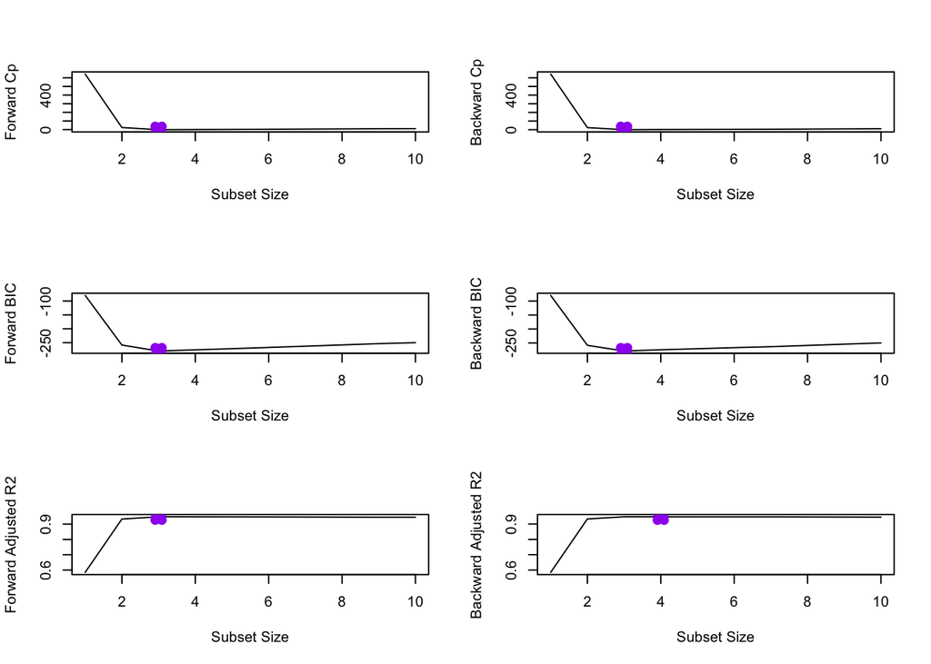

```r
# Plot
par(mfrow = c(3, 2))
plot(fwd.summary$cp, xlab = "Subset Size", ylab = "Forward Cp", pch = 20, type = "l")
points(3, fwd.summary$cp[3], pch = 4, col = "purple", lwd = 7)
plot(bwd.summary$cp, xlab = "Subset Size", ylab = "Backward Cp", pch = 20, type = "l")
points(3, bwd.summary$cp[3], pch = 4, col = "purple", lwd = 7)
plot(fwd.summary$bic, xlab = "Subset Size", ylab = "Forward BIC", pch = 20, type = "l")
points(3, fwd.summary$bic[3], pch = 4, col = "purple", lwd = 7)
plot(bwd.summary$bic, xlab = "Subset Size", ylab = "Backward BIC", pch = 20, type = "l")
points(3, bwd.summary$bic[3], pch = 4, col = "purple", lwd = 7)
plot(fwd.summary$adjr2, xlab = "Subset Size", ylab = "Forward Adjusted R2", pch = 20, type = "l")
points(3, fwd.summary$adjr2[3], pch = 4, col = "purple", lwd = 7)
plot(bwd.summary$adjr2, xlab = "Subset Size", ylab = "Backward Adjusted R2", pch = 20, type = "l")
points(4, bwd.summary$adjr2[4], pch = 4, col = "purple", lwd = 7)
```

```r
coefficients(mod.fwd, id = 3)
```

```
##           (Intercept) poly(x, 10, raw = T)1 poly(x, 10, raw = T)2
##            3.07627412            2.35623596           -3.16514887
## poly(x, 10, raw = T)7
##            0.01046843
```

```r
coefficients(mod.bwd, id = 3)
```

```
##           (Intercept) poly(x, 10, raw = T)1 poly(x, 10, raw = T)2
##           3.078881355           2.419817953          -3.177235617
## poly(x, 10, raw = T)9
##           0.001870457
```

```r
coefficients(mod.bwd, id = 4)
```

```
##           (Intercept) poly(x, 10, raw = T)1 poly(x, 10, raw = T)2
##          3.0854225293          2.4238853837         -3.1920278379
## poly(x, 10, raw = T)8 poly(x, 10, raw = T)9
##          0.0001942784          0.0018322061
```

Overall, the estimated coefficients were close to the true $\beta$ values. The forward stepwise model with 3 variables produced estimates most similar to the true coefficients, followed by the backward stepwise models with 3 and 4 variables.

#### Lasso & cv

```r
xmat = model.matrix(y ~ poly(x, 10, raw = T), data = data.full)[, -1]
mod.lasso = cv.glmnet(xmat, Y, alpha = 1)
best.lambda = mod.lasso$lambda.min
best.lambda
```

```
## [1] 0.03991416
```

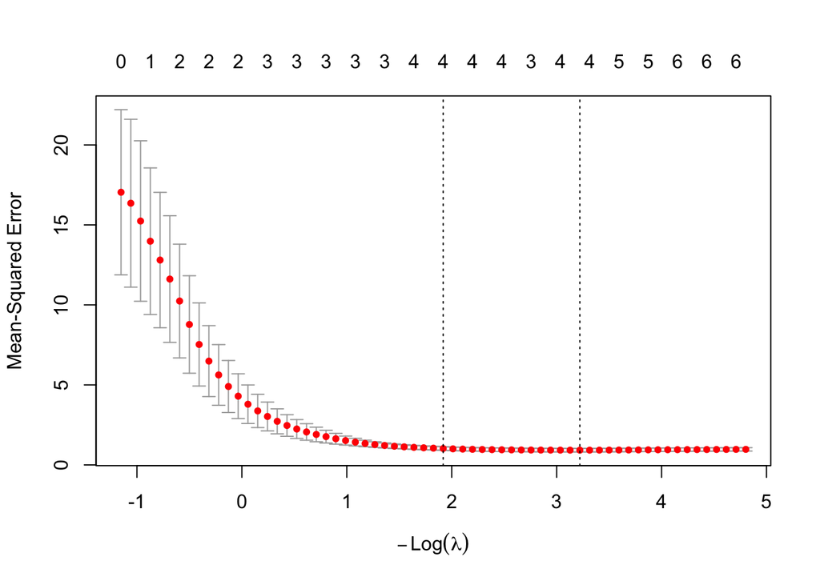

```r
plot(mod.lasso)
```

```r
# Fitting the model on entire data using best lambda
best.model = glmnet(xmat, Y, alpha = 1)
predict(best.model, s = best.lambda, type = "coefficients")
```

```
## 11 x 1 sparse Matrix of class "dgCMatrix"
##                         s=0.03991416
## (Intercept)             3.0398151056
## poly(x, 10, raw = T)1   2.2303371338
## poly(x, 10, raw = T)2  -3.1033192679
## poly(x, 10, raw = T)3   .
## poly(x, 10, raw = T)4   .
## poly(x, 10, raw = T)5   0.0498410763
## poly(x, 10, raw = T)6   .
## poly(x, 10, raw = T)7   0.0008068431
## poly(x, 10, raw = T)8   .
## poly(x, 10, raw = T)9   .
## poly(x, 10, raw = T)10  .
```

**Comment:** The lasso model was fitted using cross-validation to select the optimal penalty parameter $\lambda$. The best value obtained was $\lambda$ = 0.0399. The lasso retained the polynomial terms $X^1$, $X^2$, $X^5$, and $X^7$, while all higher-order terms were set to zero. The estimated coefficients were close to the true $\beta$ values, suggesting that lasso effectively identified the key predictors and removed irrelevant terms.

#### Best subset selection and lasso for a response vector $Y$ according to the model $$Y = \beta_0 + \beta_7X^7 + \epsilon,$$

```r
beta7 = 7
Y = beta0 + beta7 * X^7 + eps
# Predict using regsubsets
data.full = data.frame(y = Y, x = X)
mod.full = regsubsets(y ~ poly(x, 10, raw = T), data = data.full, nvmax = 10)
mod.summary = summary(mod.full)
mod.summary
```

```
## Subset selection object
## Call: regsubsets.formula(y ~ poly(x, 10, raw = T), data = data.full,
##     nvmax = 10)
## 10 Variables  (and intercept)
##                        Forced in Forced out
## poly(x, 10, raw = T)1      FALSE      FALSE
## poly(x, 10, raw = T)2      FALSE      FALSE
## poly(x, 10, raw = T)3      FALSE      FALSE
## poly(x, 10, raw = T)4      FALSE      FALSE
## poly(x, 10, raw = T)5      FALSE      FALSE
## poly(x, 10, raw = T)6      FALSE      FALSE
## poly(x, 10, raw = T)7      FALSE      FALSE
## poly(x, 10, raw = T)8      FALSE      FALSE
## poly(x, 10, raw = T)9      FALSE      FALSE
## poly(x, 10, raw = T)10     FALSE      FALSE
## 1 subsets of each size up to 10
## Selection Algorithm: exhaustive
##           poly(x, 10, raw = T)1 poly(x, 10, raw = T)2 poly(x, 10, raw = T)3
## 1  ( 1 )  " "                   " "                   " "
## 2  ( 1 )  " "                   "*"                   " "
## 3  ( 1 )  " "                   "*"                   " "
## 4  ( 1 )  "*"                   "*"                   "*"
## 5  ( 1 )  "*"                   "*"                   "*"
## 6  ( 1 )  "*"                   " "                   "*"
## 7  ( 1 )  "*"                   " "                   "*"
## 8  ( 1 )  "*"                   "*"                   "*"
## 9  ( 1 )  "*"                   "*"                   "*"
## 10  ( 1 ) "*"                   "*"                   "*"
##           poly(x, 10, raw = T)4 poly(x, 10, raw = T)5 poly(x, 10, raw = T)6
## 1  ( 1 )  " "                   " "                   " "
## 2  ( 1 )  " "                   " "                   " "
## 3  ( 1 )  " "                   "*"                   " "
## 4  ( 1 )  " "                   " "                   " "
## 5  ( 1 )  "*"                   " "                   " "
## 6  ( 1 )  " "                   " "                   "*"
## 7  ( 1 )  " "                   "*"                   "*"
## 8  ( 1 )  "*"                   " "                   "*"
## 9  ( 1 )  "*"                   " "                   "*"
## 10  ( 1 ) "*"                   "*"                   "*"
##           poly(x, 10, raw = T)7 poly(x, 10, raw = T)8 poly(x, 10, raw = T)9
## 1  ( 1 )  "*"                   " "                   " "
## 2  ( 1 )  "*"                   " "                   " "
## 3  ( 1 )  "*"                   " "                   " "
## 4  ( 1 )  "*"                   " "                   " "
## 5  ( 1 )  "*"                   " "                   " "
## 6  ( 1 )  "*"                   "*"                   " "
## 7  ( 1 )  "*"                   "*"                   " "
## 8  ( 1 )  "*"                   "*"                   " "
## 9  ( 1 )  "*"                   "*"                   "*"
## 10  ( 1 ) "*"                   "*"                   "*"
##           poly(x, 10, raw = T)10
## 1  ( 1 )  " "
## 2  ( 1 )  " "
## 3  ( 1 )  " "
## 4  ( 1 )  " "
## 5  ( 1 )  " "
## 6  ( 1 )  "*"
## 7  ( 1 )  "*"
## 8  ( 1 )  "*"
## 9  ( 1 )  "*"
## 10  ( 1 ) "*"
```

```r
# Model size for best cp, BIC and adjr2
which.min(mod.summary$cp)
```

```
## [1] 2
```

```r
which.min(mod.summary$bic)
```

```
## [1] 1
```

```r
which.max(mod.summary$adjr2)
```

```
## [1] 4
```

```r
coefficients(mod.full, id = 1)
```

```
##           (Intercept) poly(x, 10, raw = T)7
##               2.95894               7.00077
```

```r
coefficients(mod.full, id = 2)
```

```
##           (Intercept) poly(x, 10, raw = T)2 poly(x, 10, raw = T)7
##             3.0704904            -0.1417084             7.0015552
```

```r
coefficients(mod.full, id = 4)
```

```
##           (Intercept) poly(x, 10, raw = T)1 poly(x, 10, raw = T)2
##             3.0762524             0.2914016            -0.1617671
## poly(x, 10, raw = T)3 poly(x, 10, raw = T)7
##            -0.2526527             7.0091338
```

```r
xmat = model.matrix(y ~ poly(x, 10, raw = T), data = data.full)[, -1]
mod.lasso = cv.glmnet(xmat, Y, alpha = 1)
best.lambda = mod.lasso$lambda.min
best.lambda
```

```
## [1] 12.36884
```

```r
best.model = glmnet(xmat, Y, alpha = 1)
predict(best.model, s = best.lambda, type = "coefficients")
```

```
## 11 x 1 sparse Matrix of class "dgCMatrix"
##                        s=12.36884
## (Intercept)              3.820215
## poly(x, 10, raw = T)1    .
## poly(x, 10, raw = T)2    .
## poly(x, 10, raw = T)3    .
## poly(x, 10, raw = T)4    .
## poly(x, 10, raw = T)5    .
## poly(x, 10, raw = T)6    .
## poly(x, 10, raw = T)7    6.796694
## poly(x, 10, raw = T)8    .
## poly(x, 10, raw = T)9    .
## poly(x, 10, raw = T)10   .
```

**Comment:**  
When the true model was generated as $Y = 3 + 7X^7 + \epsilon$, both best subset selection and lasso regression successfully identified $X^7$ as the key predictor.

In the best subset selection: The BIC criterion selected a 1-variable model containing only $X^7$, which matches the true underlying model.  
The Cp and adjusted $R^2$ criteria selected slightly larger models (2- and 4-variable models, respectively), but in all cases $X^7$ remained the dominant term with an estimated coefficient around 7, very close to the true value.

For the lasso model, the optimal tuning parameter ($\lambda = 12.37$) showed the result where only $X^7$ was retained (coefficient=6.797), and all other coefficients were shrunk to zero.

Overall, both methods accurately recovered the true underlying relationship. The lasso provided an especially clear solution by automatically performing variable selection and shrinkage, confirming its advantage in identifying the most relevant predictor when the true model is sparse.

## Prediction

#### Training and test sets

```r
set.seed(1)
sum(is.na(College))
```

```
## [1] 0
```

```r
train.size = dim(College)[1] / 2
train = sample(1:dim(College)[1], train.size)
test = -train
College.train = College[train, ]
College.test = College[test, ]
```

#### Least squares linear model

```r
lm.fit = lm(Apps~., data=College.train)
lm.pred = predict(lm.fit, College.test)
mean((College.test[, "Apps"] - lm.pred)^2)
```

```
## [1] 1135758
```

**Comment:**  
The mean squared error (MSE) on the test set was 1135758, indicating the average squared difference between the predicted and actual number of applications in the test data.

#### Ridge regression model ($\lambda$ chosen by cross-validation)

```r
train.mat = model.matrix(Apps~., data=College.train)
test.mat = model.matrix(Apps~., data=College.test)
grid = 10 ^ seq(4, -2, length=100)

mod.ridge = cv.glmnet(train.mat, College.train[, "Apps"], alpha=0, lambda=grid, thresh=1e-12)
lambda.best = mod.ridge$lambda.min
lambda.best
```

```
## [1] 0.01
```

```r
ridge.pred = predict(mod.ridge, newx=test.mat, s=lambda.best)
mean((College.test[, "Apps"] - ridge.pred)^2)
```

```
## [1] 1135714
```

**Comment:**  
The best value of $\lambda$ was 0.01. The mean squared error (MSE) on the test set was 1135714, which is very similar to the test error obtained from the linear regression model, indicating that ridge regularization provided little improvement in this case.

#### Lasso model ($\lambda$ chosen by cross-validation)

```r
mod.lasso = cv.glmnet(train.mat, College.train[, "Apps"], alpha=1, lambda=grid, thresh=1e-12)
lambda.best = mod.lasso$lambda.min
lambda.best
```

```
## [1] 0.01
```

```r
lasso.pred = predict(mod.lasso, newx=test.mat, s=lambda.best)
mean((College.test[, "Apps"] - lasso.pred)^2)
```

```
## [1] 1135660
```

**Comment:**  
The best value of $\lambda$ was 0.01, and the mean squared error (MSE) on the test set was 1135660. This result is very close to the test MSEs from both the linear regression (1135758) and ridge regression (1135714) models, suggesting that lasso regularization did not substantially improve prediction accuracy in this dataset. The similarity in test errors across models implies that the predictors in the College dataset are moderately correlated, and the model complexity is already well captured by the linear regression without severe overfitting. The regularization penalty in the lasso model mainly served to slightly shrink coefficient magnitudes rather than exclude predictors entirely.

The estimated coefficients at $\lambda = 0.01$ were:

```r
mod.lasso = glmnet(model.matrix(Apps~., data=College), College[, "Apps"], alpha=1)
predict(mod.lasso, s=lambda.best, type="coefficients")
```

```
## 19 x 1 sparse Matrix of class "dgCMatrix"
##                    s=0.01
## (Intercept) -471.39372052
## (Intercept)    .
## PrivateYes  -491.04485137
## Accept         1.57033288
## Enroll        -0.75961467
## Top10perc     48.14698892
## Top25perc    -12.84690695
## F.Undergrad    0.04149116
## P.Undergrad    0.04438973
## Outstate      -0.08328388
## Room.Board     0.14943472
## Books          0.01532293
## Personal       0.02909954
## PhD           -8.39597537
## Terminal      -3.26800340
## S.F.Ratio     14.59298267
## perc.alumni   -0.04404771
## Expend         0.07712632
## Grad.Rate      8.28950241
```

**Comment:**  
The similar MSEs across OLS, ridge, and lasso indicate that the models generalize comparably well to the test data.

The lasso regression performs on par with ridge and OLS models in terms of prediction error, while offering slightly better regularization and interpretability through coefficient shrinkage. However, because no variables were excluded, the lasso’s advantage in model simplification was limited in this case.

#### PCR model ($M$ chosen by cross-validation)

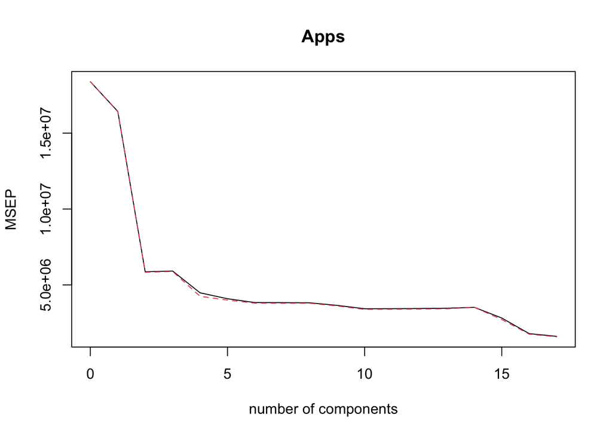

```r
pcr.fit = pcr(Apps~., data=College.train, scale=T, validation="CV")
validationplot(pcr.fit, val.type="MSEP")
```

```r
pcr.pred = predict(pcr.fit, College.test, ncomp=9)
mean((College.test[, "Apps"] - as.numeric(pcr.pred))^2)
```

```
## [1] 1583520
```

#### PLS model ($M$ chosen by cross-validation)

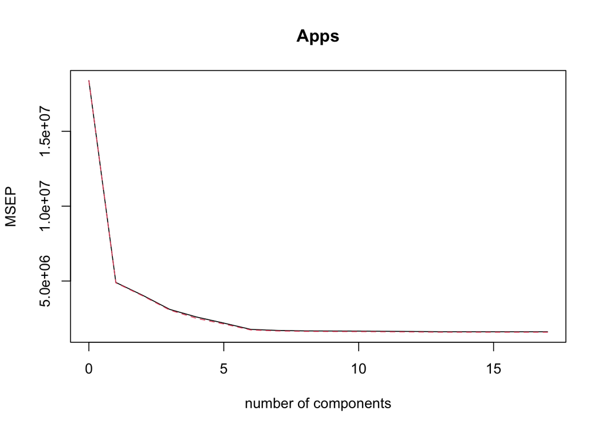

```r
pls.fit = plsr(Apps~., data=College.train, scale=T, validation="CV")
validationplot(pls.fit, val.type="MSEP")
```

```r
pls.pred = predict(pls.fit, College.test, ncomp=6)
mean((College.test[, "Apps"] - as.numeric(pls.pred))^2)
```

```
## [1] 1066991
```

**Comment:**  
A partial least squares (PLS) regression model was fitted on the training data with cross-validation to select the optimal number of components $M$. From the cross-validation plot of MSEP, the test error decreases sharply within the first few components and levels off around 5–7 components, indicating that using approximately 6 components provides an optimal balance between bias and variance.

Using $M = 6$ components, the test mean squared error (MSE) was 1066991, which is slightly lower than those from the linear (1135758), ridge (1135714), and lasso (1135660) models, and considerably lower than the PCR model (1583520). The PLS model outperformed the other methods in predictive accuracy, achieving the lowest test MSE.

In conclusion, the PLS model with 6 components achieved the best test performance among all models evaluated. This demonstrates that incorporating the response into component construction enables PLS to more effectively balance dimensionality reduction and predictive accuracy.

#### Interpretation

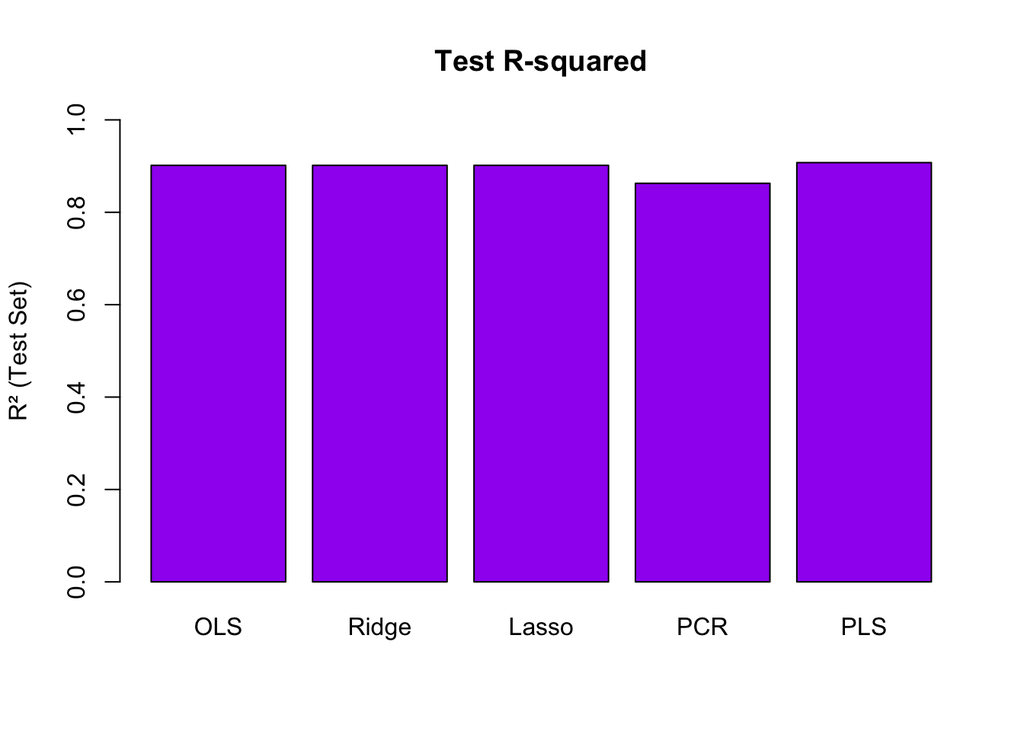

```r
test.avg = mean(College.test[, "Apps"])

# Linear regression
lm.test.r2 = 1 - mean((College.test[, "Apps"] - lm.pred)^2) /
  mean((College.test[, "Apps"] - test.avg)^2)

# Ridge regression
ridge.test.r2 = 1 - mean((College.test[, "Apps"] - ridge.pred)^2) /
  mean((College.test[, "Apps"] - test.avg)^2)

# Lasso regression
lasso.test.r2 = 1 - mean((College.test[, "Apps"] - lasso.pred)^2) /
  mean((College.test[, "Apps"] - test.avg)^2)

# PCR (ncomp = 9)
pcr.test.r2 = 1 - mean((College.test[, "Apps"] - as.numeric(pcr.pred))^2) /
  mean((College.test[, "Apps"] - test.avg)^2)

# PLS (ncomp = 6)
pls.test.r2 = 1 - mean((College.test[, "Apps"] - as.numeric(pls.pred))^2) /
  mean((College.test[, "Apps"] - test.avg)^2)

# Compare model performance
barplot(c(lm.test.r2, ridge.test.r2, lasso.test.r2, pcr.test.r2, pls.test.r2),
        names.arg = c("OLS", "Ridge", "Lasso", "PCR", "PLS"),
        col = "purple", main = "Test R-squared",
        ylab = "R² (Test Set)", ylim = c(0, 1))
```

Among the methods, **PLS** achieved the highest test $R^2$, followed closely by **ridge**, **lasso**, and **OLS**, while **PCR** had a slightly lower $R^2$. These differences, however, are minimal, suggesting that the choice of regularization or dimensionality reduction technique has little impact on predictive accuracy for this dataset.

**Conclusion:** All five methods yield strong predictive performance, with **PLS** providing the best generalization and **PCR** performing slightly worse. The results suggest that simple linear regression already performs well for this dataset, and more complex methods offer only marginal improvement.